# 02 - Alpha Diversity Analysis

Author

Francesc Català-Moll

Published

November 11, 2025

Modified

November 11, 2025

## 1 Define the input and output paths

> [!IMPORTANT] Because this was a randomized clinical trial, randomization ensures that baseline characteristics are, on average, balanced across treatment arms, minimizing the risk of confounding. Therefore, all analyses were performed using treatment assignment as the primary exposure variable. Adjustment for baseline covariates (age, sex, and risk group) was included solely to increase precision and account for inter-individual variability, not to control for confounding. Only baseline values were used for these covariates, as post-baseline measurements could be affected by treatment or follow-up time and would therefore not be appropriate for adjustment.

```r
# input
tse_file <- here::here("data", "processed", "tse_cleaned.rds")
igc_file <- here::here("data", "raw", "dataTable.rds")

# output
out_dir <- here::here("data", "02_alpha_diversity")
dir.create(out_dir, showWarnings = FALSE, recursive = TRUE)

# confounders
confounders <- c(
  "treatment",
  "time_point",
  "gender",
  "risk_group",
  "record_id",
  "age"
)

# formula
mod_formula <- glue::glue(
  "ly ~ treatment * time_point + gender + scale(age, center = TRUE, scale = FALSE) + risk_group + (1|record_id)"
)
```

## 2 Set-up

```r
# load libraries
library(magrittr)
library(patchwork)
library(tidyplots)
suppressPackageStartupMessages(library(tidySingleCellExperiment))
```

## 3 Computate Alpha Diversity Metrics

### 3.1 Load TreeSE

```r
# load
tse <- readr::read_rds(tse_file)
```

### 3.2 Add Gene Richness

```r
# load
igc_df <- readr::read_rds(igc_file) %>% tibble::as_tibble()

# threshold
threshold <-
  igc_df %>%
  dplyr::group_by(SampleID) %>%
  dplyr::summarise(NumberMappedReads = max(NumberMappedReads)) %>%
  dplyr::summarise(q = quantile(NumberMappedReads, 0.02)) %>%
  dplyr::pull()

# extract
igc_df <-
  igc_df %>%
  dplyr::filter(ReadCountReal >= threshold) %>%
  dplyr::group_by(SampleID) %>%
  dplyr::summarise(gene_richness = min(GeneNumber))

# merge
tse <- tse %>% dplyr::left_join(igc_df, by = "SampleID")
# transform
tse <- mia::transformAssay(tse, method = "relab")
```

### 3.3 Compute Alpha Diversity Metrics

```r
# select metrics
metrics <- c(
  "shannon_diversity", "gini_dominance","observed_richness", "pielou_evenness"
)

# compute
tse <-
  tse %>%
  mia::addAlpha(
    index = metrics,
    sample = quantile(colSums(assay(tse, "counts")), 0.02),
    niter = 10,
    BPPARAM = BiocParallel::MulticoreParam()
  )
```

## 4 Plot Alpha Diversity Metrics

### 4.1 Using wilcox.test

Although is not appropriate for longitudinal data, because there is no independence between samples, we can use it to get a first idea of the differences between treatments.

```r
plt_list <-
  c(metrics, "gene_richness") %>%
  purrr::set_names() %>%
  purrr::map( ~ {
    # prepare data
    plt_df <- colData(tse) %>% tibble::as_tibble()

    # calculate stats
    stats_2 <-
      plt_df %>%
      rstatix::group_by(treatment) %>%
      rstatix::wilcox_test(
        formula = formula(glue::glue("{.x} ~ time_point")),
        p.adjust.method = "fdr"
      ) %>%
      rstatix::add_significance() %>%
      rstatix::add_xy_position(x = "time_point", group = "treatment") %>%
      dplyr::mutate(y.position = y.position)

    # plot
    plt <-
      plt_df %>%
      tidyr::drop_na(!!dplyr::sym(.x)) %>%
      tidyplots::tidyplot(x = time_point, y = !!dplyr::sym(.x), colour = treatment) %>%
      tidyplots::add_boxplot(show_outliers = FALSE) %>%
      tidyplots::add_data_points_jitter(alpha = 0.4) %>%
      tidyplots::add_test_asterisks(
        method = "wilcox_test", hide_info = TRUE, bracket.nudge.y = 0.05, tip.length = 0.01
      ) %>%
      tidyplots::add(ggpubr::stat_pvalue_manual(
        stats_2, label = "p.adj.signif", hide.ns = TRUE, tip.length = 0.01,
      )) %>%
      tidyplots::adjust_x_axis_title("Time Point (weeks)") %>%
      tidyplots::adjust_legend_title("Treatment") %>%
      tidyplots::adjust_y_axis_title(
        .x %>% stringr::str_replace_all("_", " ") %>% stringr::str_to_title()
      ) %>%
      tidyplots::adjust_colors(tidyplots::colors_discrete_friendly)

    if (.x == "gene_richness") {
      plt <- plt %>% tidyplots::adjust_y_axis(labels = scales::scientific)
    }

    # save
    plt %>%
      tidyplots::adjust_size(width = 40, height = 40, unit = "mm") %>%
      tidyplots::save_plot(
        here::here(out_dir, glue::glue("alpha_{.x}.pdf")),
        view_plot = FALSE
      )

    plt
  })
```

**shannon_diversity**

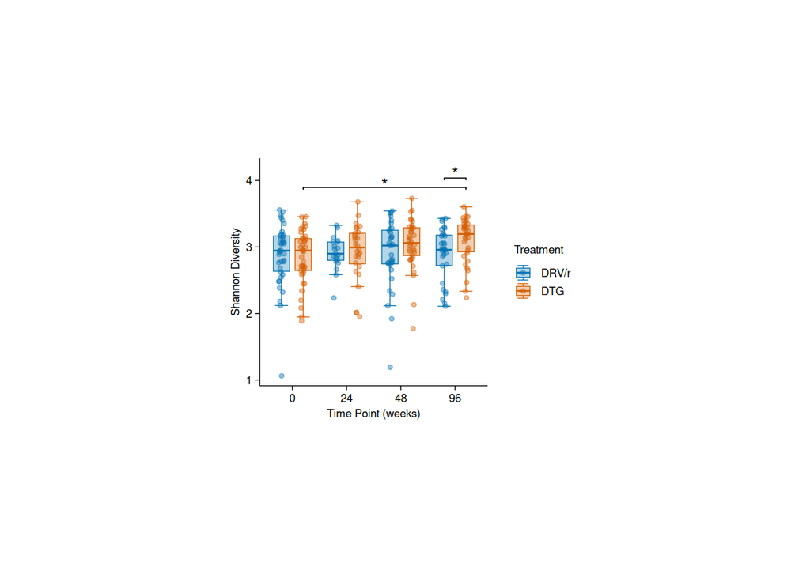

**gini_dominance**

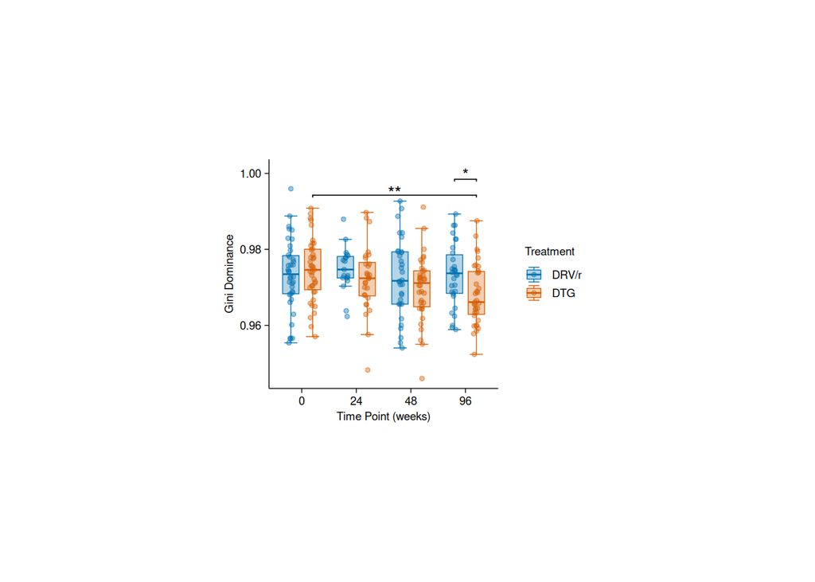

**observed_richness**

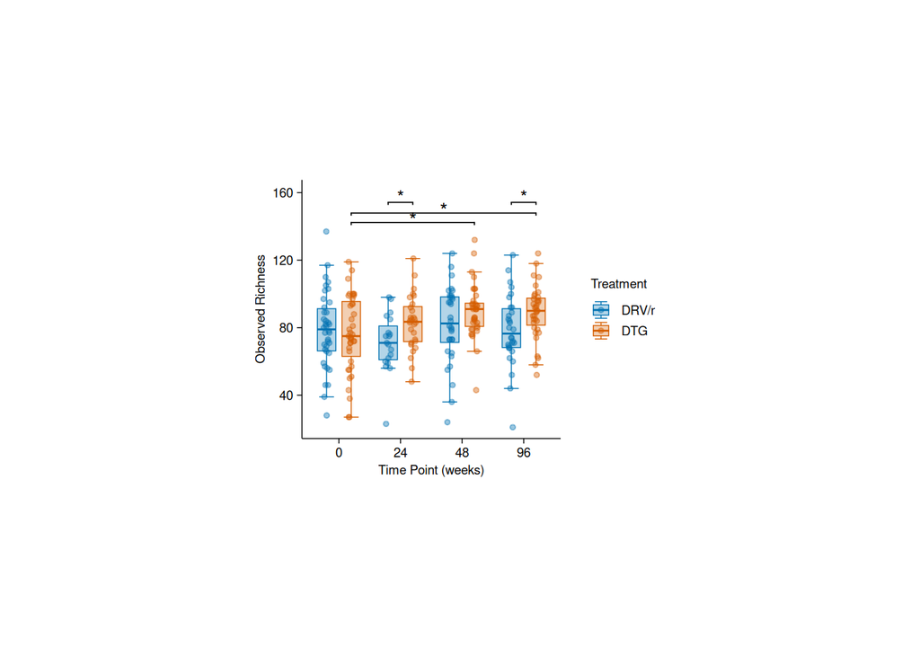

**pielou_evenness**

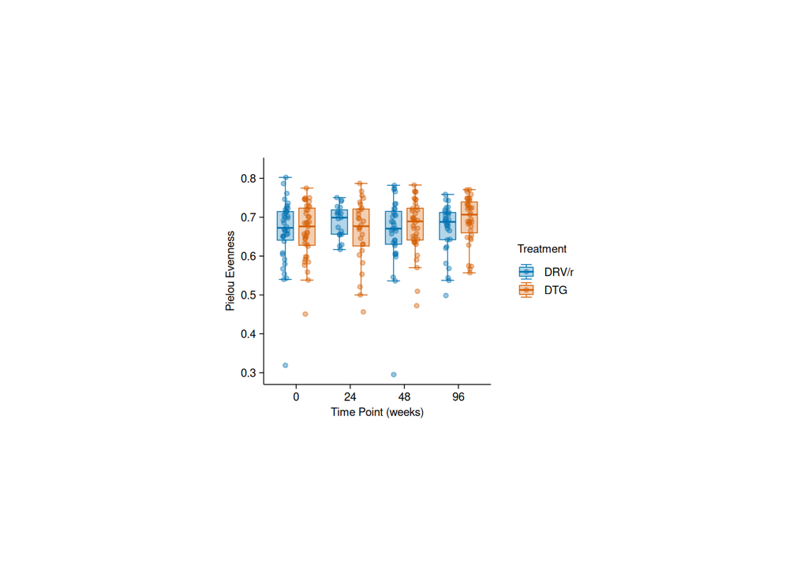

**gene_richness**

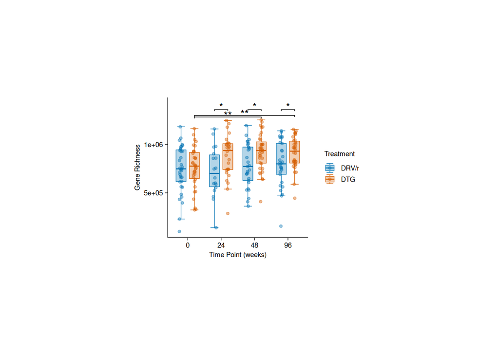

### 4.2 Using Linear Mixed Models

```r
plt_list <-
  c(metrics, "gene_richness") %>%
  purrr::set_names() %>%
  purrr::map( ~ {
    .metric <- rlang::sym(.x)
    baseline_tp = "0"

    # prepare data
    plt_df <-
      colData(tse) %>%
      tibble::as_tibble() %>%
      dplyr::select(dplyr::all_of(c(confounders, .x))) %>%
      dplyr::arrange(record_id, time_point) %>%
      tidyr::drop_na(dplyr::all_of(.metric)) %>%
      dplyr::mutate(
        dplyr::across(dplyr::where(is.character), as.factor),
        treatment = factor(treatment, levels = c("DRV/r", "DTG")),
        tp = as.character(time_point) %>% as.numeric(),
        ly = log2(!!dplyr::sym(.x) + 1e-6)
      )

    # contrasts
    tp_levels <- levels(plt_df$time_point)
    contr_list <- setNames(
      lapply(tp_levels[tp_levels != baseline_tp], function(tp) {
        w <- setNames(rep(0, length(tp_levels)), tp_levels)
        w[tp] <- 1; w[baseline_tp] <- -1
        w
      }),
      paste0(tp_levels[tp_levels != baseline_tp], " - ", baseline_tp)
    )

    # lmm
    lmm_res <-
      stats::as.formula(mod_formula) %>%
      lmerTest::lmer(data = plt_df)

    # emmeans: changes vs basal inside each treatment
    lon_contrast_df <-
      lmm_res %>%
      emmeans::emmeans(~ time_point | treatment) %>%
      emmeans::contrast(contr_list, adjust = "fdr") %>%
      broom.mixed::tidy(conf.int = TRUE) %>%
      dplyr::mutate(
        contrast_clean = stringr::str_remove_all(contrast, "time_point"),
        time_point = readr::parse_number(contrast_clean) %>% as.character()
      )

    # stub de basal a 0 sin IC
    baseline_stub <-
      emmeans::emmeans(lmm_res, ~ time_point | treatment) %>%
      broom.mixed::tidy() %>%
      dplyr::filter(time_point == baseline_tp) %>%
      dplyr::transmute(
        treatment,
        estimate = 0,
        conf.low = 0,
        conf.high = 0,
        adj.p.value = NA_real_,
        time_point = baseline_tp
      )

    lon_contrast_df <- dplyr::bind_rows(baseline_stub, lon_contrast_df)

    # emmeand by group
    group_contrast_df <-
      lmm_res %>%
      emmeans::emmeans(~ treatment | time_point) %>%
      emmeans::contrast(method = "revpairwise", adjust = "fdr") %>%
      broom.mixed::tidy(conf.int = TRUE) %>%
      dplyr::mutate(p.adj.global = p.adjust(p.value, method = "fdr")) %>%
      rstatix::add_significance(p.col = "p.adj.global")

    # forest plot by group
    forest_plt_group <-
      group_contrast_df %>%
      tidyplots::tidyplot(x = estimate, y = time_point) %>%
      tidyplots::add(geom_pointrange(
        aes(xmin = conf.low, xmax = conf.high),
        alpha = 0.8,
        position = position_dodge(width = 0.6),
        size = 2/ggplot2::.pt,
        colour = "#252525"
      )) %>%
      tidyplots::add_reference_lines(x = 0) %>%
      tidyplots::add(geom_text(
        aes(
          x = conf.high * 1.2,
          label = dplyr::if_else(p.adj.global.signif != "ns", p.adj.global.signif, "")
        ),
        position = position_dodge(width = 0.6),
        size = 7,
        hjust = 0,
        colour = "black"
      )) %>%
      tidyplots::add(expand_limits(x = max(group_contrast_df$conf.high, na.rm = TRUE) * 1.25)) %>%
      tidyplots::adjust_x_axis_title("Δ log2 ratio (DTG - DRV/r)") %>%
      tidyplots::adjust_y_axis_title("Time point (weeks)")

    # Trajectory plot
    traj_plt <-
      lon_contrast_df %>%
      dplyr::mutate(teatment = factor(treatment, levels = c("DRV/r", "DTG"))) %>%
      tidyplots::tidyplot(
        x = time_point,
        y = estimate,
        colour = treatment,
        group = treatment
      ) %>%
      tidyplots::add(geom_pointrange(
        aes(ymin = conf.low, ymax = conf.high),
        alpha = 0.8,
        size = 2/ggplot2::.pt,
        position = position_dodge(width = 1/ggplot2::.pt)
      )) %>%
      tidyplots::add_line() %>%
      tidyplots::add_reference_lines(y = 0) %>%
      tidyplots::adjust_x_axis_title("Time Point (weeks)") %>%
      tidyplots::adjust_y_axis_title("Δ log2(outcome) vs baseline") %>%
      tidyplots::adjust_legend_title("Treatment")

    # plt list
    plt_list <- list(traj_plt = traj_plt, forest_plt_group = forest_plt_group)

    # save
    showtext::showtext_auto()
    names(plt_list) %>%
      purrr::walk(~ {
        plt_list[[.x]] %>%
          tidyplots::adjust_size(width = 40, height = 40, unit = "mm") %>%
          tidyplots::save_plot(
            here::here(out_dir, glue::glue("{.x}_{.metric}.pdf")),
            view_plot = FALSE
          )
      })

    list(
      lon_stats = lon_contrast_df %>% dplyr::mutate(metric = .x),
      grp_stats = group_contrast_df %>% dplyr::mutate(metric = .x),
      plt = wrap_plots(plt_list) + plot_layout(guides = "collect")
    )
  })


lon_stats <- plt_list %>% purrr::map_dfr(~ { .x[["lon_stats"]] })
grp_stats <- plt_list %>% purrr::map_dfr(~ { .x[["grp_stats"]] })

readr::write_csv(lon_stats, here::here(out_dir, "lmm_longitudinal_stats.csv"))
readr::write_csv(grp_stats, here::here(out_dir, "lmm_group_stats.csv"))
```

**shannon_diversity**

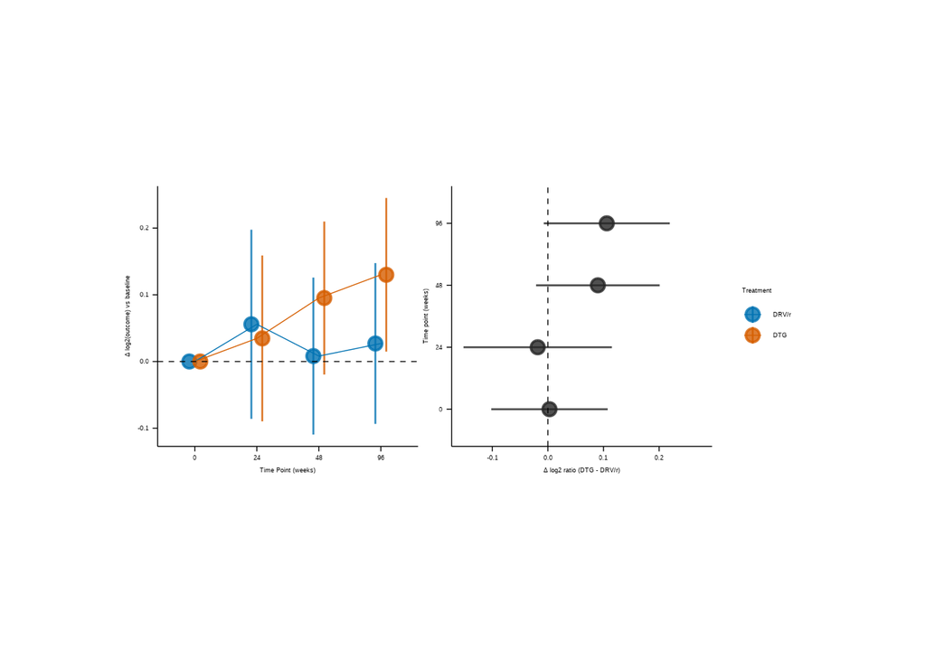

**gini_dominance**

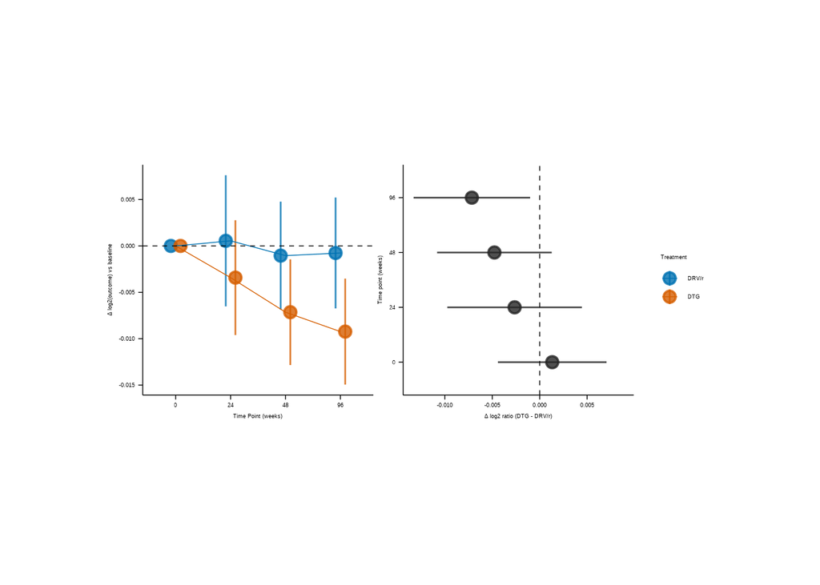